# Working Horse · Nina Branceva

Pet project · 2024

Working horse

RoleUX/UI Design

TypePet project

ToolFigma

Year2024

[figure not shown]

Overview

## Tab chaos, solved simply

Anyone who works in a browser knows the problem: dozens of open tabs, no system, constant context-switching. Existing tab managers do exist — but they're bloated with features, with steep learning curves that make them inaccessible to anyone not already invested in the tool.

Working Horse is a lightweight productivity tool designed and built from scratch to solve this one problem — without adding new ones. The entire product can be understood in four words:

Links → Folder → Open → Focus

How it was solved

## Three principles, one product

01

**A clear mental model from day one.** Folders, grouping, locking links — familiar concepts that users understand without instructions. The onboarding is built around doing, not reading: each step guides the user through a real action so they reach the product's value within the first session.

02

**Two core features, no more.** Create folders and open them all at once. That's the free product. No feature bloat, no cognitive overload — just a repeatable workflow that becomes a habit.

03

**Focus Mode as an honest premium upgrade.** Focus Mode keeps only the tabs from your chosen folder open, blocking distractions. It's paid — but the free product is fully functional without it. Premium adds value, it doesn't hold core features hostage.

Monetisation philosophy

Premium features enhance focus and control. They don't restrict what the free user can do — they offer more of what power users need.

Onboarding

## Do, don't read

Instead of walkthroughs or tooltip tours, the onboarding is embedded into the interface itself. Users learn by doing — selecting links, creating a folder, locking a working context — and the system confirms progress at each step.

1st session

Core actions only. Import links, understand the mental model. Goal: reduce cognitive load and help users succeed within the first minutes.

After

Creating, renaming and deleting folders. Adding and regrouping links. Using **Lock the links** to open a folder as a focused working context.

Premium

**Focus Mode**, history and No-Go Sites — tools for deep focus, introduced only after the user understands the core product.

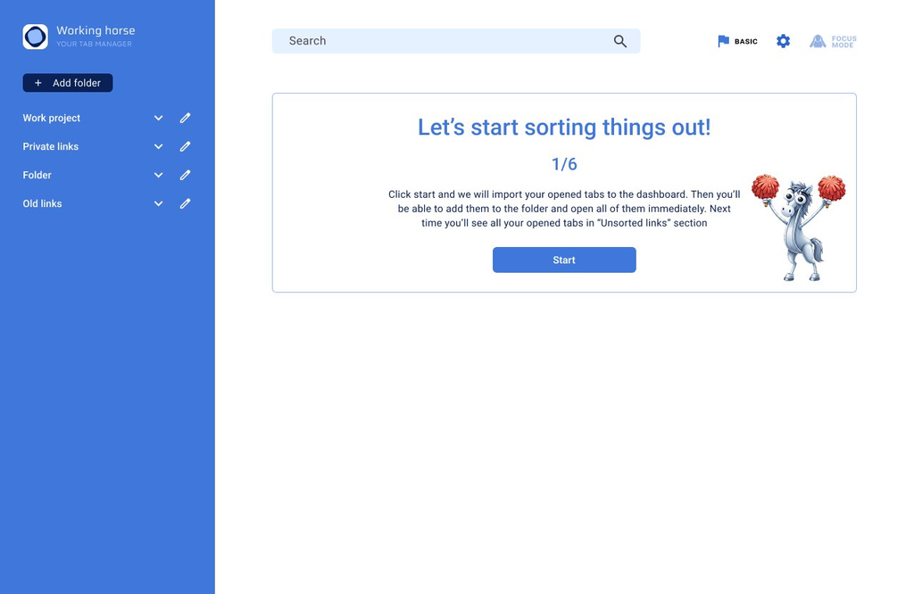

1/6 — Import your tabs

[figure not shown]

2/6 — Create first folder

[figure not shown]

2/6 — Select the links

[figure not shown]

3/6 — Add to folder

[figure not shown]

4/6 — Name the folder

[figure not shown]

4/6 — Name filled in

[figure not shown]

5/6 — See how it works

[figure not shown]

6/6 — Open your folders

[figure not shown]

Done — Congratulations

Research & iterations

## Testing & what changed

After the initial design, usability testing was conducted. Findings were structured into an affinity diagram, and key insights shaped the CJM and led to two concrete design iterations.

01

Text buttons became **more visually prominent** — users were overlooking key actions during testing.

02

Added a dedicated screen **explaining Focus Mode** before the paywall — what it does, how it helps, and why it's worth upgrading. Users need to understand what they're buying before being asked to pay.

Final designs

## The screens

[figure not shown]

[figure not shown]

[figure not shown]

[figure not shown]

[figure not shown]

[figure not shown]

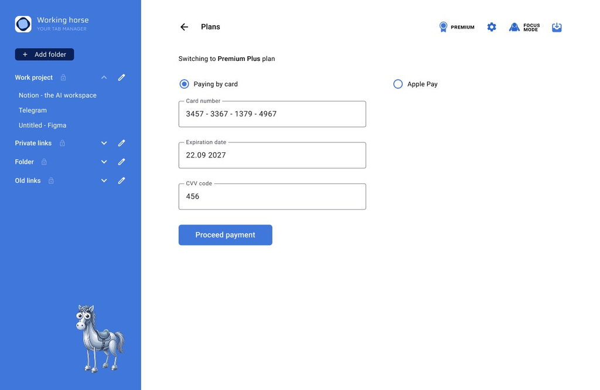

Lo-fi prototypes

## Early screens

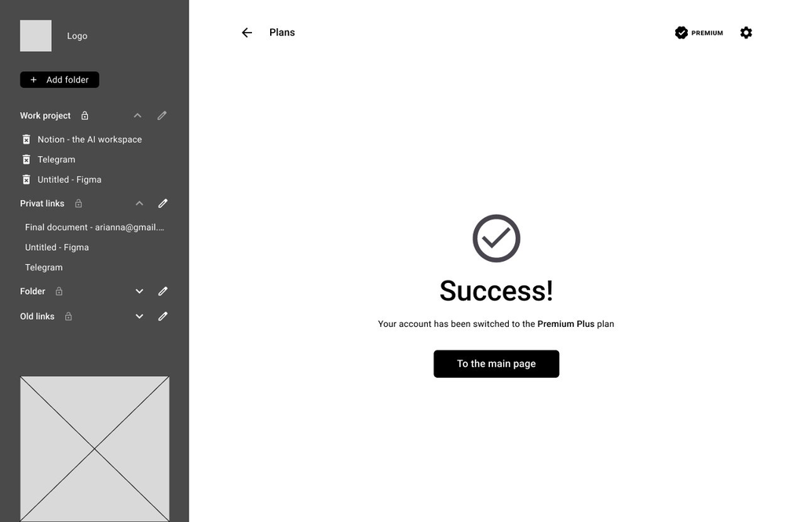

[figure not shown]

[figure not shown]

[figure not shown]

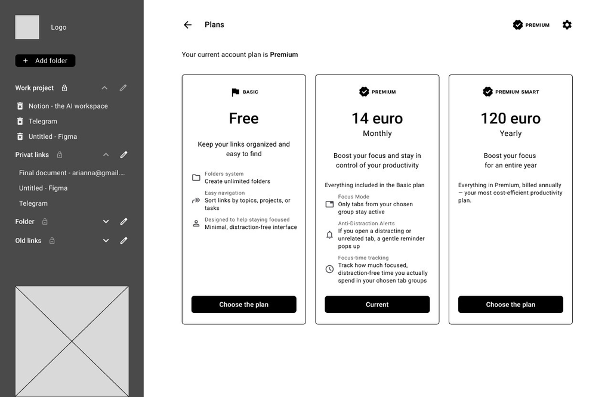

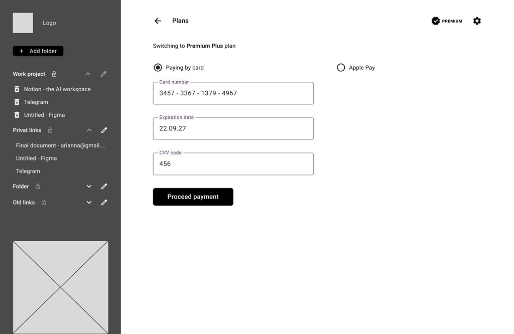

← Back to all work